# Music and Mental Health Exploratory Data Analysis

## I) Objective

### In this project, I would like to find out the following items:

#### 1) The age range of respondents participating in the survey

#### 2) Favorite music genres

#### 3) Primary music streaming services used

#### 4) Mental health survey results

#### 5) The effectiveness of music towards mental health

## II) Pseudocode

#### read in the data using pandas

#### read csv file with , as delimiter

#### preprocess the data by removing existing NA values

#### plot histogram of "Age Range Of Respondents" with matplotlib hist() function

#### plot pie chart of "Favorite Music Genres" with matplotlib pie() function

#### plot legend with Matplotlib.pyplot.legend() function

#### plot pie chart of "Music streaming platforms used" with matplotlib pie() function

#### plot histogram of "How Serious is Your Anxiety from a Scale of 1-10" with matplotlib hist() function

#### set the current tick locations and labels of the x-axis with matplotlib. pyplot. xticks() function

#### plot histogram of "How Serious is Your Depression from a Scale of 1-10" with matplotlib hist() function

#### set the current tick locations and labels of the x-axis with matplotlib. pyplot. xticks() function

#### plot histogram of "How Serious is Your Insomnia from a Scale of 1-10" with matplotlib hist() function

#### set the current tick locations and labels of the x-axis with matplotlib. pyplot. xticks() function

#### plot histogram of "How Serious is Your OCD from a Scale of 1-10" with matplotlib hist() function

#### set the current tick locations and labels of the x-axis with matplotlib. pyplot. xticks() function

#### plot pie chart of "The effectiveness of music towards mental health" with matplotlib pie() function

## III) Import Modules

```python
import pandas as pd
import numpy as np
import matplotlib.pyplot as plt
```

## IV) Input Data

```python
df = pd.read_csv("D:\Jenny\Documents\mxmh_survey_results.csv", encoding="utf-8", delimiter=",")
df
```

|  | Timestamp | Age | Primary streaming service | Hours per day | While working | Instrumentalist | Composer | Fav genre | Exploratory | Foreign languages | ... | Frequency [R&B] | Frequency [Rap] | Frequency [Rock] | Frequency [Video game music] | Anxiety | Depression | Insomnia | OCD | Music effects | Permissions |
| --- | --- | --- | --- | --- | --- | --- | --- | --- | --- | --- | --- | --- | --- | --- | --- | --- | --- | --- | --- | --- | --- |
| 0 | 8/27/2022 19:29:02 | 18.0 | Spotify | 3.0 | Yes | Yes | Yes | Latin | Yes | Yes | ... | Sometimes | Very frequently | Never | Sometimes | 3.0 | 0.0 | 1.0 | 0.0 | NaN | I understand. |
| 1 | 8/27/2022 19:57:31 | 63.0 | Pandora | 1.5 | Yes | No | No | Rock | Yes | No | ... | Sometimes | Rarely | Very frequently | Rarely | 7.0 | 2.0 | 2.0 | 1.0 | NaN | I understand. |
| 2 | 8/27/2022 21:28:18 | 18.0 | Spotify | 4.0 | No | No | No | Video game music | No | Yes | ... | Never | Rarely | Rarely | Very frequently | 7.0 | 7.0 | 10.0 | 2.0 | No effect | I understand. |
| 3 | 8/27/2022 21:40:40 | 61.0 | YouTube Music | 2.5 | Yes | No | Yes | Jazz | Yes | Yes | ... | Sometimes | Never | Never | Never | 9.0 | 7.0 | 3.0 | 3.0 | Improve | I understand. |
| 4 | 8/27/2022 21:54:47 | 18.0 | Spotify | 4.0 | Yes | No | No | R&B | Yes | No | ... | Very frequently | Very frequently | Never | Rarely | 7.0 | 2.0 | 5.0 | 9.0 | Improve | I understand. |
| ... | ... | ... | ... | ... | ... | ... | ... | ... | ... | ... | ... | ... | ... | ... | ... | ... | ... | ... | ... | ... | ... |
| 731 | 10/30/2022 14:37:28 | 17.0 | Spotify | 2.0 | Yes | Yes | No | Rock | Yes | Yes | ... | Never | Rarely | Very frequently | Never | 7.0 | 6.0 | 0.0 | 9.0 | Improve | I understand. |
| 732 | 11/1/2022 22:26:42 | 18.0 | Spotify | 1.0 | Yes | Yes | No | Pop | Yes | Yes | ... | Never | Never | Sometimes | Sometimes | 3.0 | 2.0 | 2.0 | 5.0 | Improve | I understand. |
| 733 | 11/3/2022 23:24:38 | 19.0 | Other streaming service | 6.0 | Yes | No | Yes | Rap | Yes | No | ... | Sometimes | Sometimes | Rarely | Rarely | 2.0 | 2.0 | 2.0 | 2.0 | Improve | I understand. |
| 734 | 11/4/2022 17:31:47 | 19.0 | Spotify | 5.0 | Yes | Yes | No | Classical | No | No | ... | Never | Never | Never | Sometimes | 2.0 | 3.0 | 2.0 | 1.0 | Improve | I understand. |
| 735 | 11/9/2022 1:55:20 | 29.0 | YouTube Music | 2.0 | Yes | No | No | Hip hop | Yes | Yes | ... | Very frequently | Very frequently | Very frequently | Rarely | 2.0 | 2.0 | 2.0 | 5.0 | Improve | I understand. |

736 rows × 33 columns

## V) Data Pre-processing

```python
# drop rows with existing NA values
df = df.dropna()
df
```

|  | Timestamp | Age | Primary streaming service | Hours per day | While working | Instrumentalist | Composer | Fav genre | Exploratory | Foreign languages | ... | Frequency [R&B] | Frequency [Rap] | Frequency [Rock] | Frequency [Video game music] | Anxiety | Depression | Insomnia | OCD | Music effects | Permissions |
| --- | --- | --- | --- | --- | --- | --- | --- | --- | --- | --- | --- | --- | --- | --- | --- | --- | --- | --- | --- | --- | --- |
| 2 | 8/27/2022 21:28:18 | 18.0 | Spotify | 4.0 | No | No | No | Video game music | No | Yes | ... | Never | Rarely | Rarely | Very frequently | 7.0 | 7.0 | 10.0 | 2.0 | No effect | I understand. |
| 3 | 8/27/2022 21:40:40 | 61.0 | YouTube Music | 2.5 | Yes | No | Yes | Jazz | Yes | Yes | ... | Sometimes | Never | Never | Never | 9.0 | 7.0 | 3.0 | 3.0 | Improve | I understand. |
| 4 | 8/27/2022 21:54:47 | 18.0 | Spotify | 4.0 | Yes | No | No | R&B | Yes | No | ... | Very frequently | Very frequently | Never | Rarely | 7.0 | 2.0 | 5.0 | 9.0 | Improve | I understand. |
| 5 | 8/27/2022 21:56:50 | 18.0 | Spotify | 5.0 | Yes | Yes | Yes | Jazz | Yes | Yes | ... | Very frequently | Very frequently | Very frequently | Never | 8.0 | 8.0 | 7.0 | 7.0 | Improve | I understand. |
| 6 | 8/27/2022 22:00:29 | 18.0 | YouTube Music | 3.0 | Yes | Yes | No | Video game music | Yes | Yes | ... | Rarely | Never | Never | Sometimes | 4.0 | 8.0 | 6.0 | 0.0 | Improve | I understand. |
| ... | ... | ... | ... | ... | ... | ... | ... | ... | ... | ... | ... | ... | ... | ... | ... | ... | ... | ... | ... | ... | ... |
| 731 | 10/30/2022 14:37:28 | 17.0 | Spotify | 2.0 | Yes | Yes | No | Rock | Yes | Yes | ... | Never | Rarely | Very frequently | Never | 7.0 | 6.0 | 0.0 | 9.0 | Improve | I understand. |
| 732 | 11/1/2022 22:26:42 | 18.0 | Spotify | 1.0 | Yes | Yes | No | Pop | Yes | Yes | ... | Never | Never | Sometimes | Sometimes | 3.0 | 2.0 | 2.0 | 5.0 | Improve | I understand. |
| 733 | 11/3/2022 23:24:38 | 19.0 | Other streaming service | 6.0 | Yes | No | Yes | Rap | Yes | No | ... | Sometimes | Sometimes | Rarely | Rarely | 2.0 | 2.0 | 2.0 | 2.0 | Improve | I understand. |
| 734 | 11/4/2022 17:31:47 | 19.0 | Spotify | 5.0 | Yes | Yes | No | Classical | No | No | ... | Never | Never | Never | Sometimes | 2.0 | 3.0 | 2.0 | 1.0 | Improve | I understand. |
| 735 | 11/9/2022 1:55:20 | 29.0 | YouTube Music | 2.0 | Yes | No | No | Hip hop | Yes | Yes | ... | Very frequently | Very frequently | Very frequently | Rarely | 2.0 | 2.0 | 2.0 | 5.0 | Improve | I understand. |

616 rows × 33 columns

## VI) Data Visualization

### 1) Age Range Of Respondents

```python
Z = df["Age"]
```

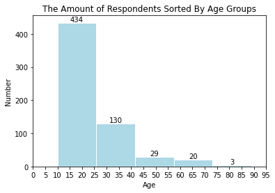

```python
fig, ax = plt.subplots()
ax.hist(Z, bins=n_bins, color=['lightblue'], ec="white")
# Set Title
ax.set_title("The Amount of Respondents Sorted By Age Groups")
# Adding Labels
ax.set_xlabel("Age")
ax.set_ylabel("Number")

# Plotting intervals of 5 with the range of 0 to 100 in the x axis
n_bins = 5
plt.xticks(range(0, 100, n_bins))

h = np.random.normal(loc=9,scale=6, size=400).astype(int)+15

for rect in ax.patches:
    height = rect.get_height()
    ax.annotate(f'{int(height)}', xy=(rect.get_x()+rect.get_width()/2, height),
                xytext=(0, 0), textcoords='offset points', ha='center', va='bottom')
```

### 2) Favorite Music Genres

```python
df["Fav genre"]
```

```
2      Video game music
3                  Jazz
4                   R&B
5                  Jazz
6      Video game music
             ...
731                Rock
732                 Pop
733                 Rap
734           Classical
735             Hip hop
Name: Fav genre, Length: 616, dtype: object
```

```python
Z = df["Fav genre"].value_counts()
Z
```

```
Rock                149
Pop                  97
Metal                77
Classical            38
Video game music     36
EDM                  36
Hip hop              32
R&B                  30
Folk                 25
K pop                21
Country              20
Rap                  20
Jazz                 19
Lofi                 10
Gospel                4
Latin                 2
Name: Fav genre, dtype: int64
```

```python
lst_genre = list(df["Fav genre"].value_counts().index)
```

[figure not shown]

```python
fig, ax = plt.subplots()
#colors
colors = ['#845EC2', '#D65DB1', '#FF6F91', '#FF9671', '#FFC75F', '#F9F871', '#2C73D2', '#757C2C', '#568242', '#33865D', '#008677', '#FFCF90', '#E9995C', '#AD652B', '#986D63', '#402E32']
labels = lst_genre
percentages = [24.2, 15.7, 12.5, 6.2, 5.8, 5.8, 5.2, 4.9, 4.1, 3.4, 3.2, 3.2, 3.1, 1.6, 0.6, 0.5]

ax.pie(Z, colors = colors, labels=labels,  autopct='%1.1f%%', startangle=90, pctdistance=0.9,radius=3.2)
labels = [f'{l}, {s:0.1f}%' for l, s in zip(labels, percentages)]
plt.legend(labels, loc='center left', bbox_to_anchor=(-3, .5), fontsize=20)

plt.tight_layout()
plt.show()
```

### 3) Music streaming platforms used

```python
 df["Primary streaming service"]
```

```
2                      Spotify
3                YouTube Music
4                      Spotify
5                      Spotify
6                YouTube Music
                ...
731                    Spotify
732                    Spotify
733    Other streaming service
734                    Spotify
735              YouTube Music
Name: Primary streaming service, Length: 616, dtype: object
```

```python
M = df["Primary streaming service"].value_counts()
M
```

```
Spotify                              396
YouTube Music                         73
I do not use a streaming service.     56
Apple Music                           42
Other streaming service               40
Pandora                                9
Name: Primary streaming service, dtype: int64
```

```python
lst_service = list(df["Primary streaming service"].value_counts().index)
```

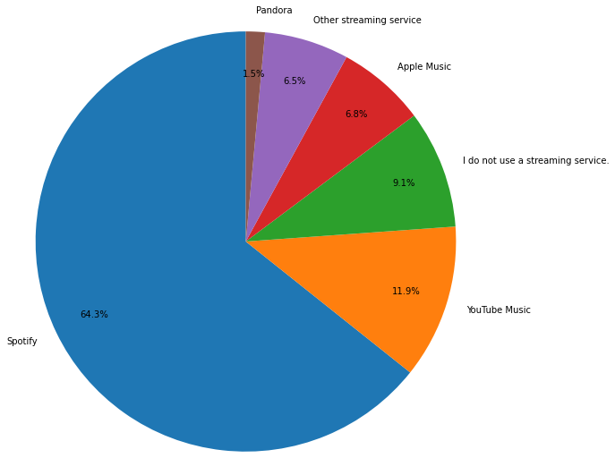

```python
fig, ax = plt.subplots()
labels = lst_service

ax.pie(M, labels=labels,  autopct='%1.1f%%', startangle=90, pctdistance=0.8,radius=2.7)
labels = [f'{l}, {s:0.1f}%' for l, s in zip(labels, percentages)]

plt.tight_layout()
plt.show()
```